# Census Data of Maryland Counties

Savannah Normand

2026-10-09

These graphs compare population trends, average population, and racial and ethnic composition across Maryland’s 23 counties and Baltimore city. Population estimates refer to July 1. Baltimore city is a county equivalent, separate from Baltimore County.

## Tidying up the data :)

```r
library(dplyr)
library(tidyr)
library(ggplot2)
library(ggrepel)

knitr::opts_chunk$set(message = FALSE, warning = FALSE, dpi = 160, out.width = "100%")

county_pop <- read.csv(
  "https://www2.census.gov/programs-surveys/popest/datasets/2020-2025/counties/totals/co-est2025-alldata.csv",
  fileEncoding = "latin1"
)

county_pop <- county_pop |>
  mutate(
    GEOID = sprintf("%02d%03d", STATE, COUNTY),
    NAME = paste0(CTYNAME, ", ", STNAME)
  ) |>
  select(
    STATE,
    COUNTY,
    GEOID,
    NAME,
    starts_with("POPESTIMATE"),
    starts_with("NPOPCHG")
  ) |>
  pivot_longer(
    cols = matches("^(POPESTIMATE|NPOPCHG)[0-9]{4}$"),
    names_to = c(".value", "year"),
    names_pattern = "(POPESTIMATE|NPOPCHG)([0-9]{4})"
  ) |>
  mutate(
    year = as.integer(year)
  ) |>
  filter(year %in% 2020:2025)

county_demo <- read.csv(
  "https://www2.census.gov/programs-surveys/popest/datasets/2020-2025/counties/asrh/cc-est2025-alldata.csv",
  fileEncoding = "latin1"
)

county_demo <- county_demo |>
  mutate(
    year = case_when(
      YEAR == 2 ~ 2020,
      YEAR == 3 ~ 2021,
      YEAR == 4 ~ 2022,
      YEAR == 5 ~ 2023,
      YEAR == 6 ~ 2024,
      YEAR == 7 ~ 2025
    ),
    GEOID = sprintf("%02d%03d", STATE, COUNTY),
    NAME = paste0(CTYNAME, ", ", STNAME)
  ) |>
  filter(year %in% 2020:2025)

county_all <- county_demo |>
  left_join(
    county_pop |>
      select(GEOID, NAME, year, POPESTIMATE, NPOPCHG),
    by = c("GEOID", "NAME", "year")
  )

county_all <- county_all |>
  select(
    GEOID,
    NAME,
    year,
    AGEGRP,
    POPESTIMATE,
    NPOPCHG,
    everything()
  )

county_all <- county_all |>
  mutate(
    across(
      where(is.character),
      ~ iconv(.x, from = "latin1", to = "UTF-8", sub = "")
    )
  )

county_all <- county_all |>
  arrange(GEOID, year, AGEGRP)

maryland <- county_all |>
  filter(STATE == 24, COUNTY != 0, AGEGRP == 0) |>
  mutate(county = sub(", Maryland$", "", NAME))
```

## Optional: My viewing and exporting of the tidy data set

```r
View(county_all)

write.csv(
  county_all,
  "C:/Users/savno/Downloads/county_population_demographics_2020_2025.csv",
  row.names = FALSE,
  fileEncoding = "UTF-8"
)
```

## Graph 1: Population change from 2020 to 2025

Five panels group counties by their 2020 population size. Every panel uses the same percentage-change scale, making changes from 2020 to 2025 easier to compare. Direct labels identify counties and their total percentage change.

```r
chart_theme <- theme_minimal(base_size = 15) +
  theme(
    plot.title = element_text(face = "bold", size = 19),
    plot.subtitle = element_text(size = 13),
    axis.title = element_text(size = 16),
    axis.text = element_text(size = 12),
    panel.grid.minor = element_blank(),
    plot.margin = margin(15, 20, 15, 15)
  )

county_levels <- sort(unique(maryland$county))
county_colors <- setNames(scales::hue_pal()(length(county_levels)), county_levels)

stopifnot(nrow(maryland) == 24 * 6,
          !anyDuplicated(maryland[c("GEOID", "year")]),
          all(is.finite(maryland$POPESTIMATE)),
          all(maryland$POPESTIMATE > 0))
```

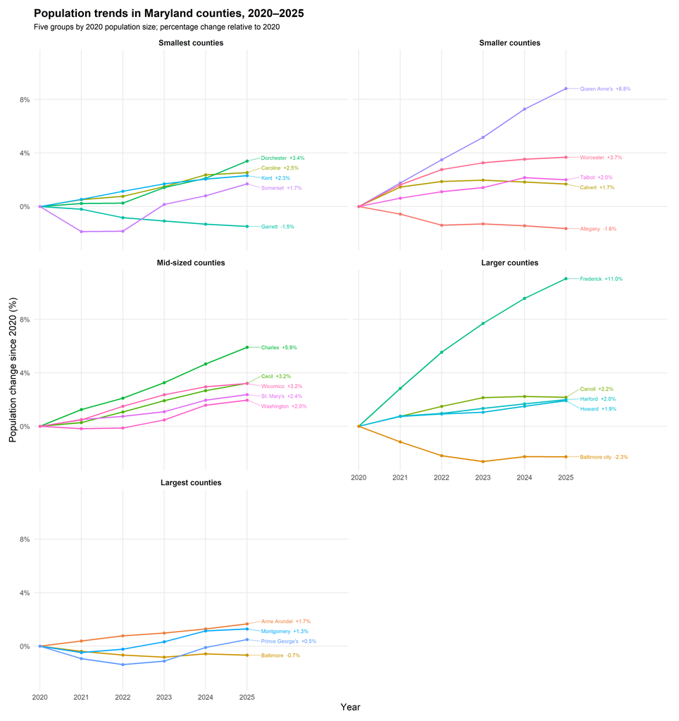

```r
trend_data <- maryland |>
  group_by(GEOID, county) |>
  mutate(percent_change = 100 * (POPESTIMATE / POPESTIMATE[year == 2020] - 1)) |>
  ungroup()

panel_groups <- trend_data |>
  filter(year == 2020) |>
  arrange(POPESTIMATE) |>
  mutate(panel = factor(ntile(POPESTIMATE, 5), levels = 1:5,
                        labels = c("Smallest counties", "Smaller counties",
                                   "Mid-sized counties", "Larger counties",
                                   "Largest counties"))) |>
  select(GEOID, panel)

trend_data <- trend_data |>
  left_join(panel_groups, by = "GEOID")

end_labels <- trend_data |>
  filter(year == 2025) |>
  mutate(label = paste0(sub(" County$", "", county), "  ",
                        sprintf("%+.1f%%", percent_change)))

graph1 <- ggplot(trend_data,
                 aes(year, percent_change, group = county, color = county)) +
  geom_line(linewidth = 1) +
  geom_point(size = 1.8) +
  geom_text_repel(
    data = end_labels, aes(label = label),
    nudge_x = 0.35, direction = "y", hjust = 0, size = 3.2,
    box.padding = 0.35, min.segment.length = 0,
    segment.alpha = 0.6, max.overlaps = Inf, seed = 24
  ) +
  scale_color_manual(values = county_colors) +
  facet_wrap(~ panel, ncol = 2) +
  scale_x_continuous(breaks = 2020:2025, limits = c(2020, 2027.3),
                     expand = expansion(mult = c(0.02, 0.02))) +
  scale_y_continuous(labels = function(x) paste0(x, "%")) +
  labs(title = "Population trends in Maryland counties, 2020–2025",
       subtitle = "Five groups by 2020 population size; percentage change relative to 2020",
       x = "Year", y = "Population change since 2020 (%)") +
  chart_theme + theme(legend.position = "none",
                      strip.text = element_text(face = "bold", size = 13))

print(graph1)
```

## Graph 2: Average county population

Each bar shows the mean of the six July population estimates, with a number label rounded to the nearest resident. Colors identify geographic groups used for this chart (listed explicitly in the code). A zero-based linear scale preserves meaningful bar lengths. A log-scale dot plot is available in the optional code below if proportional differences are the focus.

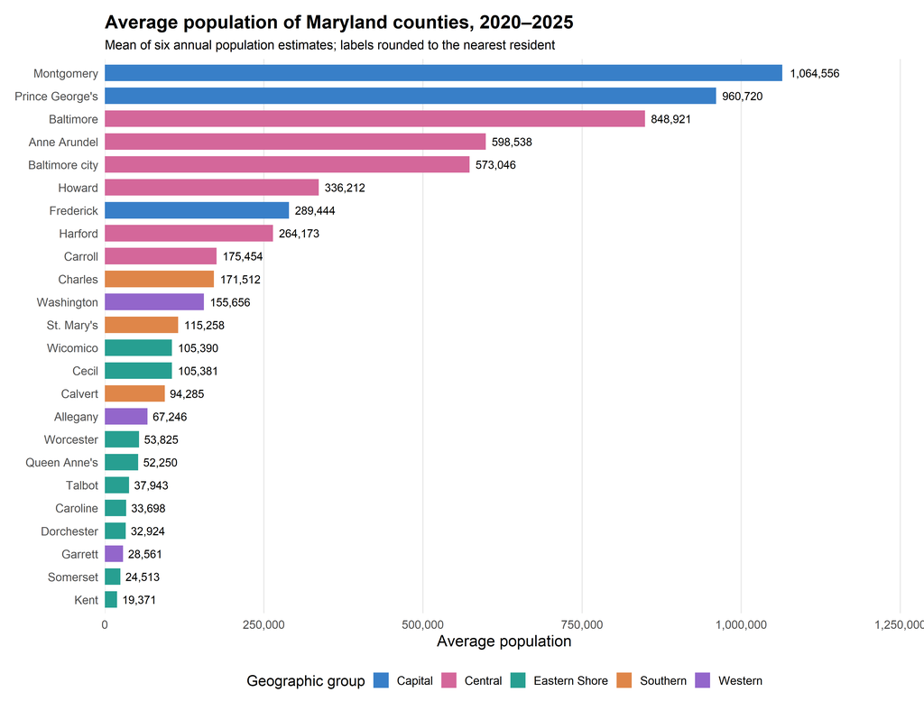

```r
average_data <- maryland |>
  group_by(GEOID, county) |>
  summarise(average_population = mean(POPESTIMATE), .groups = "drop") |>
  mutate(
    region = case_when(
      county %in% c("Allegany County", "Garrett County", "Washington County") ~ "Western",
      county %in% c("Frederick County", "Montgomery County", "Prince George's County") ~ "Capital",
      county %in% c("Calvert County", "Charles County", "St. Mary's County") ~ "Southern",
      county %in% c("Caroline County", "Cecil County", "Dorchester County", "Kent County",
                    "Queen Anne's County", "Somerset County", "Talbot County",
                    "Wicomico County", "Worcester County") ~ "Eastern Shore",
      TRUE ~ "Central"
    ),
    county = reorder(county, average_population)
  )
region_colors <- c("Western" = "#9366CB", "Capital" = "#387FC8",
                   "Southern" = "#DF8649", "Eastern Shore" = "#279F91", "Central" = "#D4679A")

graph2 <- ggplot(average_data, aes(average_population, county, fill = region)) +
  geom_col(width = 0.72) +
  geom_text(aes(label = scales::comma(round(average_population))),
            hjust = -0.15, size = 4) +
  scale_fill_manual(values = region_colors) +
  scale_x_continuous(labels = scales::label_comma(),
                     expand = expansion(mult = c(0, 0.18))) +
  scale_y_discrete(labels = function(x) sub(" County$", "", x)) +
  labs(title = "Average population of Maryland counties, 2020–2025",
       subtitle = "Mean of six annual population estimates; labels rounded to the nearest resident",
       x = "Average population", y = NULL, fill = "Geographic group") +
  chart_theme + theme(legend.position = "bottom", panel.grid.major.y = element_blank())

print(graph2)
```

```r
ggplot(average_data, aes(average_population, county, color = region)) +
  geom_point(size = 3) +
  geom_text(aes(label = scales::comma(round(average_population))), hjust = -0.2, size = 4) +
  scale_color_manual(values = region_colors) +
  scale_x_log10(labels = scales::label_comma(), expand = expansion(mult = c(0.05, 0.25))) +
  scale_y_discrete(labels = function(x) sub(" County$", "", x)) +
  labs(title = "Average county population on a log scale",
       x = "Average population (log scale)", y = NULL, color = "Geographic group") +
  chart_theme + theme(legend.position = "bottom")
```